Class, the below is a standard set of instructions for each HW, in this assignment groups will be set up for collaboration.  
Make sure your group starts one thread for the collaborative problems. You are required to participate in the collaborative problem and subproblem separately. Please do not directly post a complete solution, the goal is for the group to develop a solution after everyone has participated. Please ensure you have a write-up with solutions to each problem and subproblems, you are also required to submit code that will be compiled when grading the assignment. In each of the problems you are allowed to use built-in functions.

# **1. Module 6 - Note this is not a Collaborative Problem**

*10 Points Total*  
In this problem the goal is to build a set of numerical images from a set of arrays. The data set is from the Kaggle web site will be used: https://www.kaggle.com/c/digit-recognizer/data This data has a training.csv, test.csv and sample submission.csv files. In this exercise the focus will be on the train.csv data. The web site has the following data description:

The data files train.csv and test.csv contain gray-scale images of hand-drawn digits, from zero through nine.

Each image is 28 pixels in height and 28 pixels in width, for a total of 784 pixels in total. Each pixel has a single pixel-value associated with it, indicating the lightness or darkness of that pixel, with higher numbers meaning darker. This pixel-value is an integer between 0 and 255, inclusive.

The training data set, (train.csv), has 785 columns. The first column, called ”label”, is the digit that was drawn by the user. The rest of the columns contain the pixel-values of the associated image.

Each pixel column in the training set has a name like pixel x, where x is an integer between 0 and 783, inclusive. To locate this pixel on the image, suppose that we have decomposed x as x = i ∗ 28 + j, where i and j are integers between 0 and 27, inclusive. Then pixel x is located on row i and column j of a 28 x 28 matrix, (indexing by zero).

This data is set up in a csv file which will require the reshaping of the data to be 28 × 28 matrix representing images. There are 42000 images in the train.csv file. For this problem it is only necessary to process approximately 100 images, 10 each of the numbers from 0 through 9. The goal is to learn how to generate features from images using transforms and first order statistics.

1. [5 points] Read-in and store the data in a data structure of your choice so that the data is reshaped into a matrix of size 28 × 28 which represents each digit as an image.
2. [5 points] Display the images for indices 0, 1, 3, 6, 7, 8, 10, 11, 16, and 21. These indices represent the numerical values from 0 to 9.

```python
# import additional libraries
import pandas as pd
import matplotlib.pyplot as plt
from scipy.fftpack import dct, idct
import numpy as np

# import dataset
df = pd.read_csv("train.csv")
df.head()
```

|  | label | pixel0 | pixel1 | pixel2 | pixel3 | pixel4 | pixel5 | pixel6 | pixel7 | pixel8 | ... | pixel774 | pixel775 | pixel776 | pixel777 | pixel778 | pixel779 | pixel780 | pixel781 | pixel782 | pixel783 |
| --- | --- | --- | --- | --- | --- | --- | --- | --- | --- | --- | --- | --- | --- | --- | --- | --- | --- | --- | --- | --- | --- |
| 0 | 1 | 0 | 0 | 0 | 0 | 0 | 0 | 0 | 0 | 0 | ... | 0 | 0 | 0 | 0 | 0 | 0 | 0 | 0 | 0 | 0 |
| 1 | 0 | 0 | 0 | 0 | 0 | 0 | 0 | 0 | 0 | 0 | ... | 0 | 0 | 0 | 0 | 0 | 0 | 0 | 0 | 0 | 0 |
| 2 | 1 | 0 | 0 | 0 | 0 | 0 | 0 | 0 | 0 | 0 | ... | 0 | 0 | 0 | 0 | 0 | 0 | 0 | 0 | 0 | 0 |
| 3 | 4 | 0 | 0 | 0 | 0 | 0 | 0 | 0 | 0 | 0 | ... | 0 | 0 | 0 | 0 | 0 | 0 | 0 | 0 | 0 | 0 |
| 4 | 0 | 0 | 0 | 0 | 0 | 0 | 0 | 0 | 0 | 0 | ... | 0 | 0 | 0 | 0 | 0 | 0 | 0 | 0 | 0 | 0 |

5 rows × 785 columns

```python
## Type code here for part 1 ##
all_numbers_dict = {}
numbers_dict = {}
indices = [0,1,3,6,7,8,10,11,16,21]
for index, row in df.iterrows():
    label = f"{index}_{row.values[0]}"
    all_numbers_dict[label] = row.values[1:].reshape(28,28)
    if index in indices:
        numbers_dict[row[0]] = row.values[1:].reshape(28,28)
```

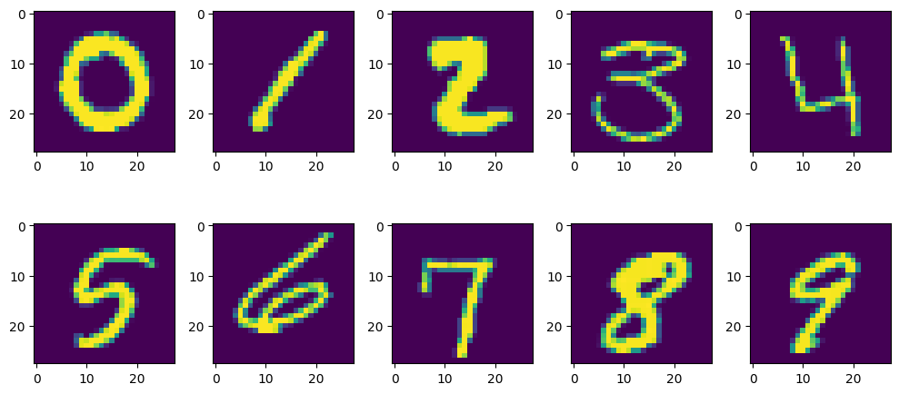

```python
## Type code here for part 2 ##
f, ax = plt.subplots(ncols=5, nrows=2, figsize=(10,5))
for count, axes in enumerate(ax.flatten()):
    axes.imshow(numbers_dict[count])
plt.tight_layout()
```

# **2. Module 6 - Note this is a Collaborative Problem**

*20 Points Total*  
In this problem each image from the train.csv (42,000 images in total) is to be processed to generate a set of features using the discrete cosine transform and Eigen decomposition.

1. [5 points] Take the 2 dimensional Discrete Cosine Transform (DCT) of each matrix from Problem 1, the matrix represents each number (0-9).
2. [2.5 points] Extract the vertical, horizontal and diagonal coefficients from the transform (using the indexes indicated by the masks provided).
3. [5 points] For each of the three sets of DCT coefficients perform Eigen decomposition.
4. [2.5 Points] Retain the top 20 Eigen vectors of each direction.
5. [5 points] Using your top Eigen vectors reduce the DCT transformed data. This will create a new data set that represents each image as a smaller subset of values.
6. Save the new data in a file of your choice, *.txt, *.csv, etc. The name is up to you (you will use this in the subsequent question).

### FFT and DCT with Inverses Code

```python
def perform_2d_dct(input_array):
    dct_array = dct(dct(input_array, axis=0, norm='ortho'), axis=1, norm='ortho')
    return dct_array

def perform_inverse_2d_dct(dct_array):
    if dct_array.ndim != 2:
        raise ValueError("Input must be a 2D array")
    inverse_dct_array = idct(idct(dct_array, axis=0, norm='ortho'), axis=1, norm='ortho')
    return inverse_dct_array
```

### DCT Masks

```python
diagMask=np.array([[0,0,0,0,0,0,0,0,0,0,0,0,0,0,0,0,0,0,0,0,0,0,0,0,0,0,0,0],
                   [0,1,0,0,0,0,0,0,0,0,0,0,0,0,0,0,0,0,0,0,0,0,0,0,0,0,0,0],
                   [0,0,1,1,0,0,0,0,0,0,0,0,0,0,0,0,0,0,0,0,0,0,0,0,0,0,0,0],
                   [0,0,1,1,1,0,0,0,0,0,0,0,0,0,0,0,0,0,0,0,0,0,0,0,0,0,0,0],
                   [0,0,0,1,1,1,0,0,0,0,0,0,0,0,0,0,0,0,0,0,0,0,0,0,0,0,0,0],
                   [0,0,0,0,1,1,1,0,0,0,0,0,0,0,0,0,0,0,0,0,0,0,0,0,0,0,0,0],
                   [0,0,0,0,0,1,1,1,1,0,0,0,0,0,0,0,0,0,0,0,0,0,0,0,0,0,0,0],
                   [0,0,0,0,0,0,1,1,1,1,1,0,0,0,0,0,0,0,0,0,0,0,0,0,0,0,0,0],
                   [0,0,0,0,0,0,1,1,1,1,1,1,1,0,0,0,0,0,0,0,0,0,0,0,0,0,0,0],
                   [0,0,0,0,0,0,0,1,1,1,1,1,1,1,1,1,0,0,0,0,0,0,0,0,0,0,0,0],
                   [0,0,0,0,0,0,0,1,1,1,1,1,1,1,1,1,1,1,1,0,0,0,0,0,0,0,0,0],
                   [0,0,0,0,0,0,0,0,1,1,1,1,1,1,1,1,1,1,1,1,1,1,0,0,0,0,0,0],
                   [0,0,0,0,0,0,0,0,1,1,1,1,1,1,1,1,1,1,1,1,1,1,1,1,1,0,0,0],
                   [0,0,0,0,0,0,0,0,0,1,1,1,1,1,1,1,1,1,1,1,1,1,1,1,1,1,1,1],
                   [0,0,0,0,0,0,0,0,0,1,1,1,1,1,1,1,1,1,1,1,1,1,1,1,1,1,1,1],
                   [0,0,0,0,0,0,0,0,0,1,1,1,1,1,1,1,1,1,1,1,1,1,1,1,1,1,1,1],
                   [0,0,0,0,0,0,0,0,0,0,1,1,1,1,1,1,1,1,1,1,1,1,1,1,1,1,1,1],
                   [0,0,0,0,0,0,0,0,0,0,1,1,1,1,1,1,1,1,1,1,1,1,1,1,1,1,1,1],
                   [0,0,0,0,0,0,0,0,0,0,1,1,1,1,1,1,1,1,1,1,1,1,1,1,1,1,1,1],
                   [0,0,0,0,0,0,0,0,0,0,0,1,1,1,1,1,1,1,1,1,1,1,1,1,1,1,1,1],
                   [0,0,0,0,0,0,0,0,0,0,0,1,1,1,1,1,1,1,1,1,1,1,1,1,1,1,1,1],
                   [0,0,0,0,0,0,0,0,0,0,0,1,1,1,1,1,1,1,1,1,1,1,1,1,1,1,1,1],
                   [0,0,0,0,0,0,0,0,0,0,0,0,1,1,1,1,1,1,1,1,1,1,1,1,1,1,1,1],
                   [0,0,0,0,0,0,0,0,0,0,0,0,1,1,1,1,1,1,1,1,1,1,1,1,1,1,1,1],
                   [0,0,0,0,0,0,0,0,0,0,0,0,1,1,1,1,1,1,1,1,1,1,1,1,1,1,1,1],
                   [0,0,0,0,0,0,0,0,0,0,0,0,0,1,1,1,1,1,1,1,1,1,1,1,1,1,1,1],
                   [0,0,0,0,0,0,0,0,0,0,0,0,0,1,1,1,1,1,1,1,1,1,1,1,1,1,1,1],
                   [0,0,0,0,0,0,0,0,0,0,0,0,0,1,1,1,1,1,1,1,1,1,1,1,1,1,1,1]
                  ])

vertMask =np.array([[0,1,1,1,1,1,1,1,1,1,1,1,1,1,1,1,1,1,1,1,1,1,1,1,1,1,1,1],
                  [0,0,1,1,1,1,1,1,1,1,1,1,1,1,1,1,1,1,1,1,1,1,1,1,1,1,1,1],
                  [0,0,0,0,1,1,1,1,1,1,1,1,1,1,1,1,1,1,1,1,1,1,1,1,1,1,1,1],
                  [0,0,0,0,0,1,1,1,1,1,1,1,1,1,1,1,1,1,1,1,1,1,1,1,1,1,1,1],
                  [0,0,0,0,0,0,1,1,1,1,1,1,1,1,1,1,1,1,1,1,1,1,1,1,1,1,1,1],
                  [0,0,0,0,0,0,0,1,1,1,1,1,1,1,1,1,1,1,1,1,1,1,1,1,1,1,1,1],
                  [0,0,0,0,0,0,0,0,0,1,1,1,1,1,1,1,1,1,1,1,1,1,1,1,1,1,1,1],
                  [0,0,0,0,0,0,0,0,0,0,0,1,1,1,1,1,1,1,1,1,1,1,1,1,1,1,1,1],
                  [0,0,0,0,0,0,0,0,0,0,0,0,0,1,1,1,1,1,1,1,1,1,1,1,1,1,1,1],
                  [0,0,0,0,0,0,0,0,0,0,0,0,0,0,0,0,1,1,1,1,1,1,1,1,1,1,1,1],
                  [0,0,0,0,0,0,0,0,0,0,0,0,0,0,0,0,0,0,0,1,1,1,1,1,1,1,1,1],
                  [0,0,0,0,0,0,0,0,0,0,0,0,0,0,0,0,0,0,0,0,0,0,1,1,1,1,1,1],
                  [0,0,0,0,0,0,0,0,0,0,0,0,0,0,0,0,0,0,0,0,0,0,0,0,0,1,1,1],
                  [0,0,0,0,0,0,0,0,0,0,0,0,0,0,0,0,0,0,0,0,0,0,0,0,0,0,0,0],
                  [0,0,0,0,0,0,0,0,0,0,0,0,0,0,0,0,0,0,0,0,0,0,0,0,0,0,0,0],
                  [0,0,0,0,0,0,0,0,0,0,0,0,0,0,0,0,0,0,0,0,0,0,0,0,0,0,0,0],
                  [0,0,0,0,0,0,0,0,0,0,0,0,0,0,0,0,0,0,0,0,0,0,0,0,0,0,0,0],
                  [0,0,0,0,0,0,0,0,0,0,0,0,0,0,0,0,0,0,0,0,0,0,0,0,0,0,0,0],
                  [0,0,0,0,0,0,0,0,0,0,0,0,0,0,0,0,0,0,0,0,0,0,0,0,0,0,0,0],
                  [0,0,0,0,0,0,0,0,0,0,0,0,0,0,0,0,0,0,0,0,0,0,0,0,0,0,0,0],
                  [0,0,0,0,0,0,0,0,0,0,0,0,0,0,0,0,0,0,0,0,0,0,0,0,0,0,0,0],
                  [0,0,0,0,0,0,0,0,0,0,0,0,0,0,0,0,0,0,0,0,0,0,0,0,0,0,0,0],
                  [0,0,0,0,0,0,0,0,0,0,0,0,0,0,0,0,0,0,0,0,0,0,0,0,0,0,0,0],
                  [0,0,0,0,0,0,0,0,0,0,0,0,0,0,0,0,0,0,0,0,0,0,0,0,0,0,0,0],
                  [0,0,0,0,0,0,0,0,0,0,0,0,0,0,0,0,0,0,0,0,0,0,0,0,0,0,0,0],
                  [0,0,0,0,0,0,0,0,0,0,0,0,0,0,0,0,0,0,0,0,0,0,0,0,0,0,0,0],
                  [0,0,0,0,0,0,0,0,0,0,0,0,0,0,0,0,0,0,0,0,0,0,0,0,0,0,0,0],
                  [0,0,0,0,0,0,0,0,0,0,0,0,0,0,0,0,0,0,0,0,0,0,0,0,0,0,0,0]
                  ])
horizMask = np.array([[ 0,0,0,0,0,0,0,0,0,0,0,0,0,0,0,0,0,0,0,0,0,0,0,0,0,0,0,0],
                    [1,0,0,0,0,0,0,0,0,0,0,0,0,0,0,0,0,0,0,0,0,0,0,0,0,0,0,0],
                    [1,1,0,0,0,0,0,0,0,0,0,0,0,0,0,0,0,0,0,0,0,0,0,0,0,0,0,0],
                    [1,1,0,0,0,0,0,0,0,0,0,0,0,0,0,0,0,0,0,0,0,0,0,0,0,0,0,0],
                    [1,1,1,0,0,0,0,0,0,0,0,0,0,0,0,0,0,0,0,0,0,0,0,0,0,0,0,0],
                    [1,1,1,1,0,0,0,0,0,0,0,0,0,0,0,0,0,0,0,0,0,0,0,0,0,0,0,0],
                    [1,1,1,1,1,0,0,0,0,0,0,0,0,0,0,0,0,0,0,0,0,0,0,0,0,0,0,0],
                    [1,1,1,1,1,1,0,0,0,0,0,0,0,0,0,0,0,0,0,0,0,0,0,0,0,0,0,0],
                    [1,1,1,1,1,1,0,0,0,0,0,0,0,0,0,0,0,0,0,0,0,0,0,0,0,0,0,0],
                    [1,1,1,1,1,1,1,0,0,0,0,0,0,0,0,0,0,0,0,0,0,0,0,0,0,0,0,0],
                    [1,1,1,1,1,1,1,0,0,0,0,0,0,0,0,0,0,0,0,0,0,0,0,0,0,0,0,0],
                    [1,1,1,1,1,1,1,1,0,0,0,0,0,0,0,0,0,0,0,0,0,0,0,0,0,0,0,0],
                    [1,1,1,1,1,1,1,1,0,0,0,0,0,0,0,0,0,0,0,0,0,0,0,0,0,0,0,0],
                    [1,1,1,1,1,1,1,1,1,0,0,0,0,0,0,0,0,0,0,0,0,0,0,0,0,0,0,0],
                    [1,1,1,1,1,1,1,1,1,0,0,0,0,0,0,0,0,0,0,0,0,0,0,0,0,0,0,0],
                    [1,1,1,1,1,1,1,1,1,0,0,0,0,0,0,0,0,0,0,0,0,0,0,0,0,0,0,0],
                    [1,1,1,1,1,1,1,1,1,1,0,0,0,0,0,0,0,0,0,0,0,0,0,0,0,0,0,0],
                    [1,1,1,1,1,1,1,1,1,1,0,0,0,0,0,0,0,0,0,0,0,0,0,0,0,0,0,0],
                    [1,1,1,1,1,1,1,1,1,1,0,0,0,0,0,0,0,0,0,0,0,0,0,0,0,0,0,0],
                    [1,1,1,1,1,1,1,1,1,1,1,0,0,0,0,0,0,0,0,0,0,0,0,0,0,0,0,0],
                    [1,1,1,1,1,1,1,1,1,1,1,0,0,0,0,0,0,0,0,0,0,0,0,0,0,0,0,0],
                    [1,1,1,1,1,1,1,1,1,1,1,0,0,0,0,0,0,0,0,0,0,0,0,0,0,0,0,0],
                    [1,1,1,1,1,1,1,1,1,1,1,1,0,0,0,0,0,0,0,0,0,0,0,0,0,0,0,0],
                    [1,1,1,1,1,1,1,1,1,1,1,1,0,0,0,0,0,0,0,0,0,0,0,0,0,0,0,0],
                    [1,1,1,1,1,1,1,1,1,1,1,1,0,0,0,0,0,0,0,0,0,0,0,0,0,0,0,0],
                    [1,1,1,1,1,1,1,1,1,1,1,1,1,0,0,0,0,0,0,0,0,0,0,0,0,0,0,0],
                    [1,1,1,1,1,1,1,1,1,1,1,1,1,0,0,0,0,0,0,0,0,0,0,0,0,0,0,0],
                    [1,1,1,1,1,1,1,1,1,1,1,1,1,0,0,0,0,0,0,0,0,0,0,0,0,0,0,0]])
```

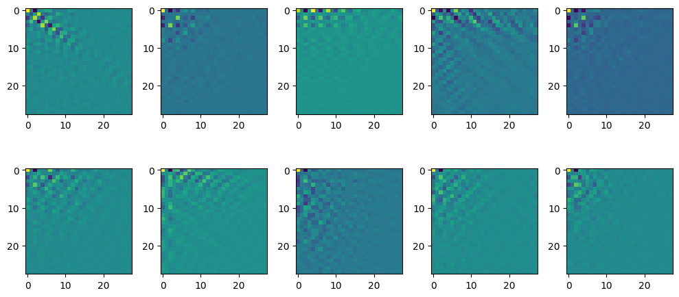

```python
## Type code here for part 1 ##
dct_array = df.iloc[:,1:].values
for count, row in enumerate(dct_array):
    transform = perform_2d_dct(row.reshape(28,28))
    dct_array[count,:] = transform.reshape(1,-1)

f, ax = plt.subplots(ncols=5, nrows=2, figsize=(10,5))
for count, axes in enumerate(ax.flatten()):
    axes.imshow(dct_array[count,:].reshape(28,28))
plt.tight_layout()
```

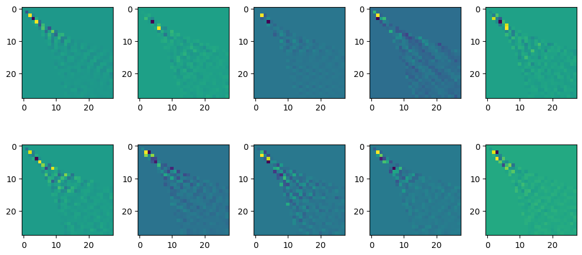

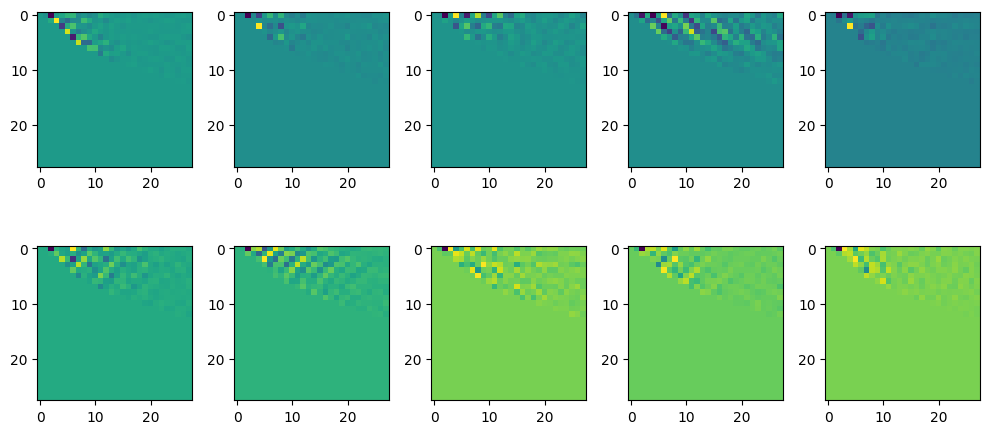

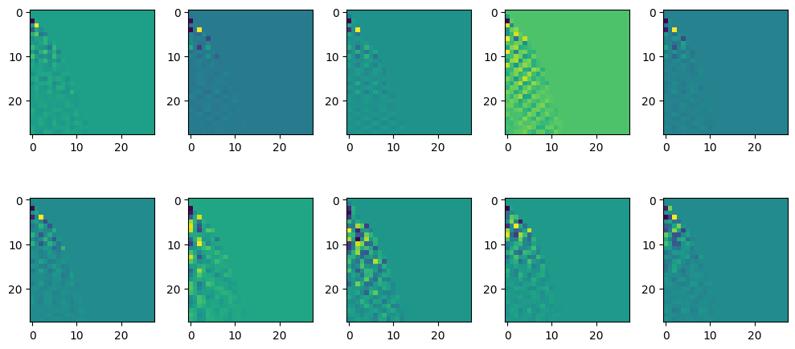

```python
## Type code here for part 2 ##

diag_array = dct_array.copy()
vert_array = dct_array.copy()
hori_array = dct_array.copy()

def mask_data(row, mask):
    masked = row.values.reshape(28,28) * mask
    return masked.reshape(1,-1)

for count, row in enumerate(dct_array):
    diag_array[count, :] = (row.reshape(28,28) * diagMask).reshape(1,-1)
    vert_array[count, :] = (row.reshape(28,28) * vertMask).reshape(1,-1)
    hori_array[count, :] = (row.reshape(28,28) * horizMask).reshape(1,-1)

f, ax = plt.subplots(ncols=5, nrows=2, figsize=(10,5))
for count, axes in enumerate(ax.flatten()):
    axes.imshow(diag_array[count,:].reshape(28,28))
plt.tight_layout()

f2, ax2 = plt.subplots(ncols=5, nrows=2, figsize=(10,5))
for count, axes in enumerate(ax2.flatten()):
    axes.imshow(vert_array[count,:].reshape(28,28))
plt.tight_layout()

f3, ax3 = plt.subplots(ncols=5, nrows=2, figsize=(10,5))
for count, axes in enumerate(ax3.flatten()):
    axes.imshow(hori_array[count,:].reshape(28,28))
plt.tight_layout()
```

```python
## Type code here for part 3 ##
covD = np.cov(diag_array.T)
_, eigen_diag = np.linalg.eig(covD)

covV = np.cov(vert_array.T)
_, eigen_vert = np.linalg.eig(covV)

covH = np.cov(hori_array.T)
_, eigen_hori = np.linalg.eig(covH)
```

```python
## Type code here for part 4 ##
eigen_diag_20 = eigen_diag[:,:20]
eigen_vert_20 = eigen_vert[:,:20]
eigen_hori_20 = eigen_hori[:,:20]
```

```python
## Type code here for part 5 ##
features = np.zeros((42000, 60))
features[:,:20] = np.dot(diag_array,eigen_diag_20)
features[:,20:40] = np.dot(vert_array,eigen_vert_20)
features[:,40:] = np.dot(hori_array,eigen_hori_20)
```

```python
## Type code here for part 6 ##
np.savetxt("ZH_trainFeatures42k.csv", features, delimiter=",")
```

# **3. Module 4 Note this is not a Collaborative Problem**

```python
# import libraries
from itertools import combinations

# read in the train features data
df_train = pd.read_csv("trainFeatures42k.csv", header=None, index_col=0)
df_train.head()
```

| 0 | 1 | 2 | 3 | 4 | 5 | 6 | 7 | 8 | 9 | 10 | ... | 51 | 52 | 53 | 54 | 55 | 56 | 57 | 58 | 59 | 60 |
| --- | --- | --- | --- | --- | --- | --- | --- | --- | --- | --- | --- | --- | --- | --- | --- | --- | --- | --- | --- | --- | --- |
| 1 | 538.267964 | -314.023125 | 443.809967 | 470.780028 | 176.561668 | -336.130920 | 23.221391 | -45.523748 | -232.436917 | -15.406905 | ... | -90.463868 | 107.934027 | 25.417533 | -97.235438 | -66.589588 | 22.468479 | -111.476083 | 62.807185 | 74.771969 | -7.480156 |
| 0 | -238.730010 | 224.609513 | -197.464121 | 23.557813 | -219.122649 | -223.695514 | -172.689736 | 125.561839 | -194.150108 | -423.697477 | ... | 44.464226 | -7.825244 | -5.260700 | 18.905444 | 9.593545 | -40.015688 | -96.469679 | 24.317962 | -137.943930 | 94.025390 |
| 1 | 51.647165 | -27.271305 | -185.258708 | -50.103687 | 216.830344 | -207.152351 | 60.301310 | 95.431402 | -117.051561 | -129.083930 | ... | -12.722596 | -3.039582 | -26.963181 | -18.563280 | 16.095458 | -81.075489 | -42.589100 | 52.083444 | -29.080312 | 42.344233 |
| 4 | 110.890600 | 62.854265 | -97.528878 | -21.291295 | 297.976619 | -32.899732 | 34.647964 | -85.574818 | -60.120835 | -7.868372 | ... | 23.112458 | -62.558569 | -115.846264 | -16.405413 | -37.548852 | -269.649782 | -130.725868 | -23.526366 | -20.448849 | 37.234782 |
| 0 | -300.296735 | 152.547221 | -91.949199 | 90.416744 | -453.385929 | -89.195463 | -15.051828 | -38.036779 | -190.363654 | -428.272606 | ... | -28.107534 | 30.400739 | -47.075128 | -13.092383 | -85.371052 | -141.450375 | -36.200100 | 114.188444 | -21.988893 | -46.480710 |

5 rows × 60 columns

```python
## Type the code for part 1 here ##
fdr_matrix = np.zeros((60, 45))

def FDR(x1, x2):
    u1 = np.mean(x1, axis=0)
    u2 = np.mean(x2, axis=0)
    sig1 = np.std(x1, axis=0)**2
    sig2 = np.var(x2, axis=0)**2
    return (u1-u2)**2 / (sig1 + sig2)

for count, comb in enumerate(combinations(range(10),2)):
    col1 = df_train.loc[comb[0], :].values
    col2 = df_train.loc[comb[1], :].values
    fdr_matrix[:, count] = FDR(col1, col2).flatten()
```

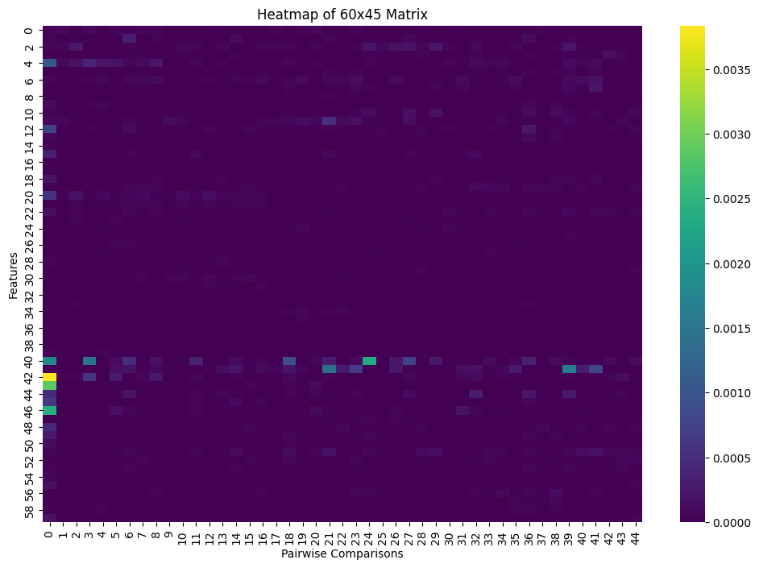

```python
# Create a heatmap
import seaborn as sns

plt.figure(figsize=(12, 8))  # Adjust figure size as needed
sns.heatmap(fdr_matrix, cmap='viridis')  # You can change the colormap as desired
plt.title('Heatmap of 60x45 Matrix')
plt.xlabel('Pairwise Comparisons')
plt.ylabel('Features')
plt.show()
```

# **4. Cross-Validation [2], [7] This is a Collaborative Problem**

*Not covered in lecture notes*  
*20 Points Total*

In this problem you are to develop and implement a k-fold cross validation algorithm. You are allowed to use either the Iris data set or the developed numerical features from HW2 to test your implementation. In this problem the following is to be completed:

1. [5 points] Develop (pseudocode) an algorithm to randomly shuffle input data. Then divide the data into groups of testing and training sets based on the number of desired folds/experiments, the term used will be k-fold cross validation. Use the 5-fold cross validation in Figure 1 as a reference.
2. [5 points] Implement your k-fold cross validation algorithm.
3. [5 points] Test your implementation using the numerical features generated question 2.
4. [5 points] Perform analysis to determine if your implementation is correct. Explain your method of analysis and conclusions.

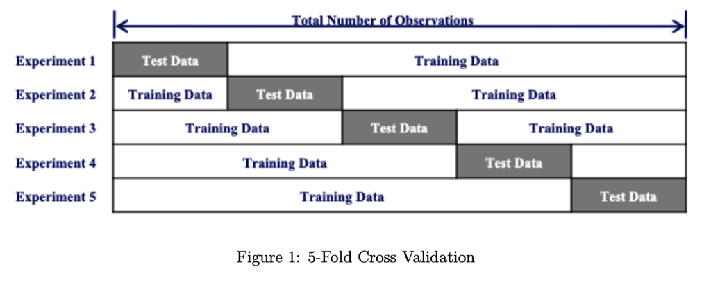

```python
%matplotlib inline
from IPython.display import Image
Image('cross_val.png')
```

# Type your psuedocode for part 1 here

```
Algorithm kFoldCrossValidation(data, k=5)
    shuffledData = shuffle(data)
    foldSize = length(shuffledData) / k
    folds = []

    for i from 0 to k-1
        start = i * foldSize
        end = start + foldSize
        fold = shuffledData[start:end]
        folds.append(fold)

    for i from 0 to k-1
        testSet = folds[i]
        trainingSet = []

        for j from 0 to k-1
            if j != i
                trainingSet.extend(folds[j])

        yield (trainingSet, testSet)

Procedure shuffle(data)
    for i from length(data)-1 down to 1
        j = random integer between 0 and i
        swap data[i] with data[j]

    return data
```

[output not shown]

```python
## Type response to part 2 here ##
def k_fold_cross_validation(data: pd.DataFrame, k=5):
    data = data.sample(frac=1).reset_index(drop=True)
    fold_size = len(data) // k
    folds = {}

    for i in range(k):
        start = i * fold_size
        end = start + fold_size
        folds[i] = data.iloc[start:end,:]

    for i in range(k):
        test_set = folds[i]
        training_set = []

        for j in range(k):
            if j != i:
                training_set.extend(folds[j].index)

        training_data = data.loc[training_set,:]

        yield training_data, test_set,
```

```python
## Type the code for part 3 here ##
df_train_indexed = df_train.reset_index()
fold = 0
training_data = {}
testing_data = {}
training_labels = {}
for train, test in k_fold_cross_validation(df_train_indexed, k=5):
    print(f"Fold {fold} Training Dataset:")
    display(train.head())
    training_data[fold] = train
    testing_data[fold] = test
    fold += 1
```

```
Fold 0 Training Dataset:
```

|  | 0 | 1 | 2 | 3 | 4 | 5 | 6 | 7 | 8 | 9 | ... | 51 | 52 | 53 | 54 | 55 | 56 | 57 | 58 | 59 | 60 |
| --- | --- | --- | --- | --- | --- | --- | --- | --- | --- | --- | --- | --- | --- | --- | --- | --- | --- | --- | --- | --- | --- |
| 8400 | 1 | 34.203919 | 36.470449 | -179.422746 | 19.742098 | 219.151021 | -164.747334 | 67.273115 | 33.323109 | -114.632299 | ... | 16.730983 | -19.990667 | -37.368749 | -18.373514 | 3.100243 | -71.530441 | -41.619020 | 18.200506 | -63.749544 | 19.604631 |
| 8401 | 7 | 446.103946 | -33.672328 | -350.564072 | -329.129767 | -63.697690 | -163.039512 | 736.331296 | 75.682065 | -255.320965 | ... | -63.667399 | -47.272518 | -143.163373 | 8.182572 | 162.703470 | 6.778475 | -101.808635 | 197.245955 | 30.661206 | 33.735886 |
| 8402 | 2 | 273.604138 | -151.595150 | -285.646234 | -158.500839 | 132.788583 | -155.352013 | 192.795564 | -117.928356 | -398.906013 | ... | -395.663642 | 261.807431 | 83.150034 | -183.594108 | 151.363730 | -22.716699 | -202.476531 | -102.782670 | -338.107625 | -26.985382 |
| 8403 | 3 | -484.088285 | -83.030379 | 261.906675 | -17.335168 | 190.444831 | -397.074798 | 76.515780 | 145.555107 | -282.369161 | ... | 12.929719 | -191.538465 | -102.833427 | -27.522175 | 12.397859 | -149.072566 | -226.217281 | 2.745203 | -199.271623 | 161.416761 |
| 8404 | 4 | 111.228189 | 234.017058 | -405.142410 | 169.210868 | 505.468061 | 5.707239 | 4.329762 | -381.891401 | 179.702388 | ... | -115.476736 | -290.612457 | 140.164680 | -23.516381 | -64.110349 | -419.081329 | -198.212278 | -295.571323 | 64.187553 | -170.022817 |

5 rows × 61 columns

```
Fold 1 Training Dataset:
```

|  | 0 | 1 | 2 | 3 | 4 | 5 | 6 | 7 | 8 | 9 | ... | 51 | 52 | 53 | 54 | 55 | 56 | 57 | 58 | 59 | 60 |
| --- | --- | --- | --- | --- | --- | --- | --- | --- | --- | --- | --- | --- | --- | --- | --- | --- | --- | --- | --- | --- | --- |
| 0 | 0 | -475.825436 | -456.161122 | -296.074899 | 180.718125 | -182.645824 | -240.378405 | 165.261430 | 169.229757 | 144.362379 | ... | 224.040158 | -165.548109 | -156.665762 | 173.680913 | 49.399496 | -44.410928 | -165.240939 | 116.764617 | -96.470364 | 49.162970 |
| 1 | 9 | 258.290825 | 387.357086 | -94.529163 | -5.040716 | 242.200973 | 26.934195 | 185.176376 | 76.435597 | -2.516435 | ... | -249.993517 | -169.451620 | 244.420600 | -122.126419 | 5.001618 | 145.724612 | -20.329365 | -13.824689 | 106.747495 | -62.585729 |
| 2 | 5 | 47.205793 | -279.101546 | 81.086410 | -63.197501 | 205.568387 | -128.970629 | 88.074213 | 198.015770 | -91.752312 | ... | 82.098116 | 113.381794 | -214.067442 | -134.380090 | 179.089848 | 204.787640 | -120.925171 | -348.730669 | 33.881702 | 48.450668 |
| 3 | 4 | 384.425621 | -109.057742 | -23.219487 | -396.548529 | 127.643026 | -360.643681 | 343.482561 | 99.558744 | -262.171939 | ... | 196.023359 | 18.558094 | 125.535014 | -212.340864 | 122.343124 | -49.660992 | 37.080347 | 138.330200 | 17.370302 | 136.704600 |
| 4 | 8 | 504.701644 | 310.308485 | -112.942961 | 229.519091 | 260.972196 | -208.101237 | 320.023940 | 105.483184 | 227.391764 | ... | 121.855087 | 107.397048 | 32.450038 | -372.238244 | 96.691988 | -110.400209 | 185.058947 | -16.165380 | 104.035809 | -40.612044 |

5 rows × 61 columns

```
Fold 2 Training Dataset:
```

|  | 0 | 1 | 2 | 3 | 4 | 5 | 6 | 7 | 8 | 9 | ... | 51 | 52 | 53 | 54 | 55 | 56 | 57 | 58 | 59 | 60 |
| --- | --- | --- | --- | --- | --- | --- | --- | --- | --- | --- | --- | --- | --- | --- | --- | --- | --- | --- | --- | --- | --- |
| 0 | 0 | -475.825436 | -456.161122 | -296.074899 | 180.718125 | -182.645824 | -240.378405 | 165.261430 | 169.229757 | 144.362379 | ... | 224.040158 | -165.548109 | -156.665762 | 173.680913 | 49.399496 | -44.410928 | -165.240939 | 116.764617 | -96.470364 | 49.162970 |
| 1 | 9 | 258.290825 | 387.357086 | -94.529163 | -5.040716 | 242.200973 | 26.934195 | 185.176376 | 76.435597 | -2.516435 | ... | -249.993517 | -169.451620 | 244.420600 | -122.126419 | 5.001618 | 145.724612 | -20.329365 | -13.824689 | 106.747495 | -62.585729 |
| 2 | 5 | 47.205793 | -279.101546 | 81.086410 | -63.197501 | 205.568387 | -128.970629 | 88.074213 | 198.015770 | -91.752312 | ... | 82.098116 | 113.381794 | -214.067442 | -134.380090 | 179.089848 | 204.787640 | -120.925171 | -348.730669 | 33.881702 | 48.450668 |
| 3 | 4 | 384.425621 | -109.057742 | -23.219487 | -396.548529 | 127.643026 | -360.643681 | 343.482561 | 99.558744 | -262.171939 | ... | 196.023359 | 18.558094 | 125.535014 | -212.340864 | 122.343124 | -49.660992 | 37.080347 | 138.330200 | 17.370302 | 136.704600 |
| 4 | 8 | 504.701644 | 310.308485 | -112.942961 | 229.519091 | 260.972196 | -208.101237 | 320.023940 | 105.483184 | 227.391764 | ... | 121.855087 | 107.397048 | 32.450038 | -372.238244 | 96.691988 | -110.400209 | 185.058947 | -16.165380 | 104.035809 | -40.612044 |

5 rows × 61 columns

```
Fold 3 Training Dataset:
```

|  | 0 | 1 | 2 | 3 | 4 | 5 | 6 | 7 | 8 | 9 | ... | 51 | 52 | 53 | 54 | 55 | 56 | 57 | 58 | 59 | 60 |
| --- | --- | --- | --- | --- | --- | --- | --- | --- | --- | --- | --- | --- | --- | --- | --- | --- | --- | --- | --- | --- | --- |
| 0 | 0 | -475.825436 | -456.161122 | -296.074899 | 180.718125 | -182.645824 | -240.378405 | 165.261430 | 169.229757 | 144.362379 | ... | 224.040158 | -165.548109 | -156.665762 | 173.680913 | 49.399496 | -44.410928 | -165.240939 | 116.764617 | -96.470364 | 49.162970 |
| 1 | 9 | 258.290825 | 387.357086 | -94.529163 | -5.040716 | 242.200973 | 26.934195 | 185.176376 | 76.435597 | -2.516435 | ... | -249.993517 | -169.451620 | 244.420600 | -122.126419 | 5.001618 | 145.724612 | -20.329365 | -13.824689 | 106.747495 | -62.585729 |
| 2 | 5 | 47.205793 | -279.101546 | 81.086410 | -63.197501 | 205.568387 | -128.970629 | 88.074213 | 198.015770 | -91.752312 | ... | 82.098116 | 113.381794 | -214.067442 | -134.380090 | 179.089848 | 204.787640 | -120.925171 | -348.730669 | 33.881702 | 48.450668 |
| 3 | 4 | 384.425621 | -109.057742 | -23.219487 | -396.548529 | 127.643026 | -360.643681 | 343.482561 | 99.558744 | -262.171939 | ... | 196.023359 | 18.558094 | 125.535014 | -212.340864 | 122.343124 | -49.660992 | 37.080347 | 138.330200 | 17.370302 | 136.704600 |
| 4 | 8 | 504.701644 | 310.308485 | -112.942961 | 229.519091 | 260.972196 | -208.101237 | 320.023940 | 105.483184 | 227.391764 | ... | 121.855087 | 107.397048 | 32.450038 | -372.238244 | 96.691988 | -110.400209 | 185.058947 | -16.165380 | 104.035809 | -40.612044 |

5 rows × 61 columns

```
Fold 4 Training Dataset:
```

|  | 0 | 1 | 2 | 3 | 4 | 5 | 6 | 7 | 8 | 9 | ... | 51 | 52 | 53 | 54 | 55 | 56 | 57 | 58 | 59 | 60 |
| --- | --- | --- | --- | --- | --- | --- | --- | --- | --- | --- | --- | --- | --- | --- | --- | --- | --- | --- | --- | --- | --- |
| 0 | 0 | -475.825436 | -456.161122 | -296.074899 | 180.718125 | -182.645824 | -240.378405 | 165.261430 | 169.229757 | 144.362379 | ... | 224.040158 | -165.548109 | -156.665762 | 173.680913 | 49.399496 | -44.410928 | -165.240939 | 116.764617 | -96.470364 | 49.162970 |
| 1 | 9 | 258.290825 | 387.357086 | -94.529163 | -5.040716 | 242.200973 | 26.934195 | 185.176376 | 76.435597 | -2.516435 | ... | -249.993517 | -169.451620 | 244.420600 | -122.126419 | 5.001618 | 145.724612 | -20.329365 | -13.824689 | 106.747495 | -62.585729 |
| 2 | 5 | 47.205793 | -279.101546 | 81.086410 | -63.197501 | 205.568387 | -128.970629 | 88.074213 | 198.015770 | -91.752312 | ... | 82.098116 | 113.381794 | -214.067442 | -134.380090 | 179.089848 | 204.787640 | -120.925171 | -348.730669 | 33.881702 | 48.450668 |
| 3 | 4 | 384.425621 | -109.057742 | -23.219487 | -396.548529 | 127.643026 | -360.643681 | 343.482561 | 99.558744 | -262.171939 | ... | 196.023359 | 18.558094 | 125.535014 | -212.340864 | 122.343124 | -49.660992 | 37.080347 | 138.330200 | 17.370302 | 136.704600 |
| 4 | 8 | 504.701644 | 310.308485 | -112.942961 | 229.519091 | 260.972196 | -208.101237 | 320.023940 | 105.483184 | 227.391764 | ... | 121.855087 | 107.397048 | 32.450038 | -372.238244 | 96.691988 | -110.400209 | 185.058947 | -16.165380 | 104.035809 | -40.612044 |

5 rows × 61 columns

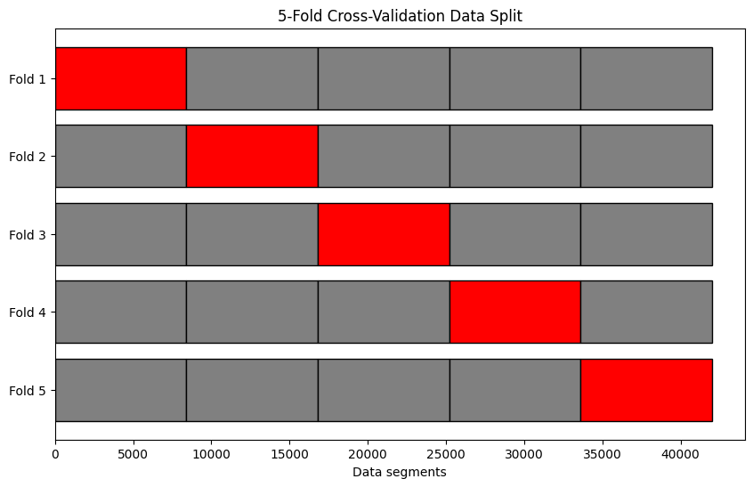

```
Fold 0: Testing Set
First Index: 0
Last Index: 8399

Fold 1: Testing Set
First Index: 8400
Last Index: 16799

Fold 2: Testing Set
First Index: 16800
Last Index: 25199

Fold 3: Testing Set
First Index: 25200
Last Index: 33599

Fold 4: Testing Set
First Index: 33600
Last Index: 41999
```

```python
## Type your code for part 4 here ##
def plot_k_fold_cross_validation(data, k=5):
    # Assuming equal fold size for simplicity
    fold_size = len(data) / k
    fig, ax = plt.subplots(figsize=(10, 6))

    for i in range(k):
        # For each fold, create a bar divided into k parts
        for j in range(k):
            if i == j:
                # Highlight the test set
                ax.barh(i, fold_size, left=j*fold_size, color='red', edgecolor='black')
            else:
                # Display the training set
                ax.barh(i, fold_size, left=j*fold_size, color='gray', edgecolor='black')

    ax.set_yticks(np.arange(k))
    ax.set_yticklabels([f'Fold {i+1}' for i in range(k)])
    ax.set_xlabel('Data segments')
    ax.set_title('5-Fold Cross-Validation Data Split')
    plt.gca().invert_yaxis()  # Invert y-axis to have Fold 1 on top
    plt.show()

plot_k_fold_cross_validation(df_train)

for key, value in testing_data.items():
    print(f"Fold {key}: Testing Set")
    print(f"First Index: {value.index[0]}")
    print(f"Last Index: {value.index[-1]}")
    print("")
```

## Explain your methods for part 4 here

In this analysis, I present a graphical representation of the distribution between the testing and training sets in the context of k-fold cross-validation. The graph vividly illustrates the partitioning of data, with the testing set highlighted in red and the training set in grey. Notably, the testing set occupies a smaller portion of the data, which systematically rotates through the dataset for each fold, ensuring comprehensive validation coverage. The training set, depicted in grey, constitutes the larger segment of the data, providing a robust basis for model training.

# **5. - Module 8 Note this is a Collaborative Problem - Parzen Window**

*30 Points Total*

In this problem the following is to be completed:

1. [10 points] Using your 5-fold cross validation implementation from Problem 4, the Gaussian kernel in Eq. 27 (Parzen Window) of the Machine Learning document, implement an algorithm to process training observations and compare with test observations.
2. [10 point] Using all observations and the petal length from the Iris data replicate the subfigures in Figure 2.
3. [10 point] Using all observations, the petal length and the petal width from the Iris data replicate the subfigures in Figure 3 without contour lines.

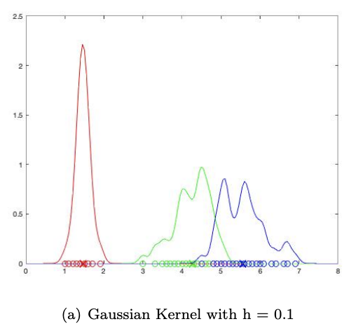

```python
Image('gk11d.png')
```

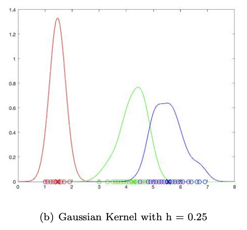

```python
Image('gk251d.png')
```

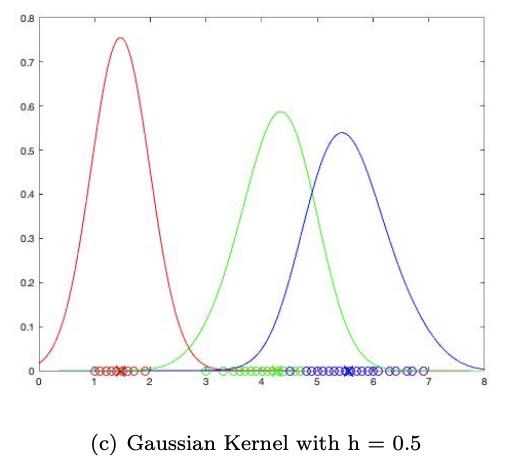

```python
Image('gk51d.png')
```

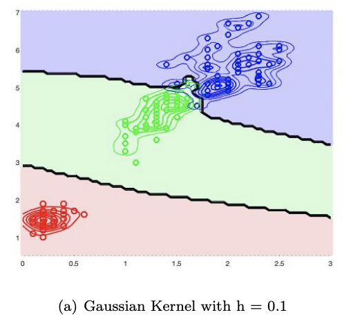

```python
Image('gk12d.png')
```

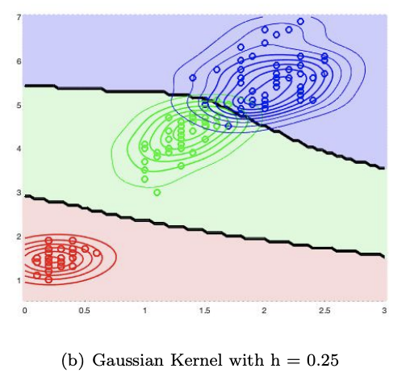

```python
Image('gk252d.png')
```

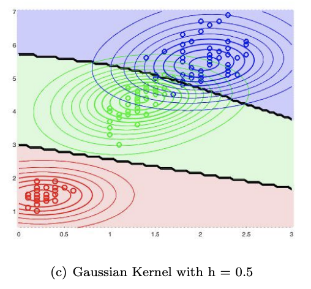

```python
Image('gk52d.png')
```

```python
## Write the code for part 1 here ##

import numpy as np

class ParzenClassifier:
   def __init__(self, h):
        self.h = h  # Bandwidth parameter
        self.classes = None
        self.class_distributions = None
        self.d = None  # Dimensionality

   def fit(self, X_train, y_train):
        self.classes = np.unique(y_train)
        self.class_distributions = [X_train[y_train == c] for c in self.classes]
        try:
            self.d = X_train.shape[1]  # Assuming features are in columns
        except IndexError:
            self.d = 1

   def predict(self, X_test):
        y_pred = []
    #    probability = []
        for x in X_test:
            probs = np.array([self.calculate_probabilities(x, data) for data in self.class_distributions])
            predicted_class = self.classes[np.argmax(probs)]
        #    probability.append(max(probs))
            y_pred.append(predicted_class)
        return y_pred

   def calculate_probabilities(self, x, class_data):
        n = len(class_data)
        probs = 0
        for x_i in class_data:
        #    u = (x - x_i) / self.h
            probs += self.calculate_kernel(x_i, x)
        return probs / (n * self.h ** self.d)

   def calculate_kernel(self, x_i, x):
        u = (x - x_i) / self.h
        return np.exp(-0.5 * np.linalg.norm(u) ** 2) / (np.sqrt(2 * np.pi) ** self.d)
```

### I am not able to figure out what I am plotting wrong in this part. It's not really making sense to me in general because the KDE plot just plots the distrution of the feature, so I'm not sure how they would change if I'm just plotting the same feature that is not affected by the h value.

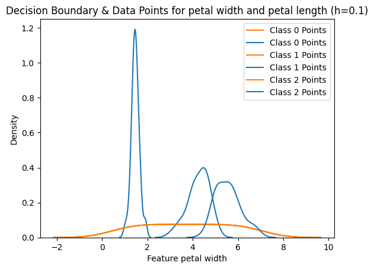

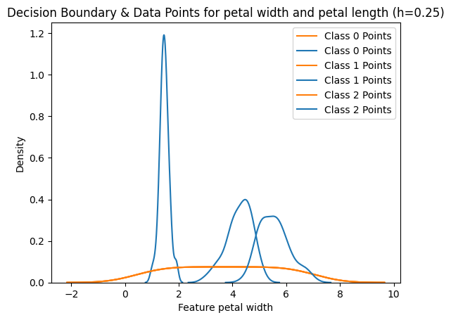

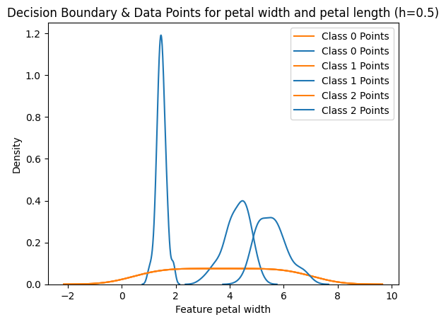

```python
## Write the code for part 2 here ##

from sklearn.datasets import load_iris

# Load the Iris dataset
iris = load_iris()

X = iris.data[:, 2]  # Features (using feature 2)
y = iris.target  # Target labels

h_values = [0.1, 0.25, 0.5]
class_colors = ['r', 'g', 'b']

for h in h_values:

    # Train the Parzen window classifier
    model = ParzenClassifier(h)  # Adjust 'h' (bandwidth) as needed
    model.fit(X, y)

    # Generate x-axis values for the feature
    x1_values = np.linspace(0.5, 7, 50)

    Z = model.predict(x1_values)
    Z = np.array(Z).reshape(x1_values.shape)

    # Plot the decision boundary and points colored by class
    # plt.contourf(X2, X1, Z, alpha=0.3, cmap='hsv', levels=np.arange(len(model.classes) + 1) - 0.5)  # Decision boundary
    for class_index in range(len(model.classes)):
        class_data = model.class_distributions[class_index]
        sns.kdeplot([class_data, x1_values], label=f"Class {model.classes[class_index]} Points", color=class_colors[class_index])

    plt.xlabel("Feature petal width")
    # plt.ylabel("Feature petal length")
    plt.title(f"Decision Boundary & Data Points for petal width and petal length (h={h})")
    plt.legend()
    plt.show()
```

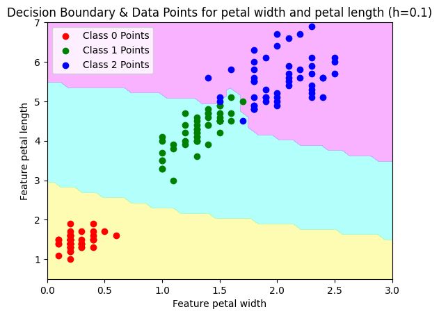

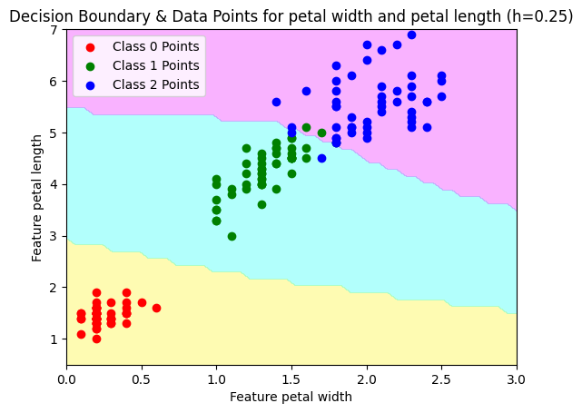

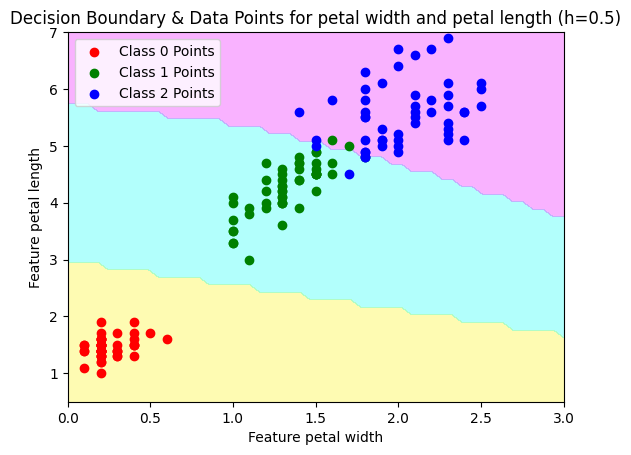

```python
## Write the code for part 3 here ##

from sklearn.datasets import load_iris

# Load the Iris dataset
iris = load_iris()

X = iris.data[:, [2, 3]]  # Features (using features 2 and 3)
y = iris.target  # Target labels

h_values = [0.1, 0.25, 0.5]
class_colors = ['r', 'g', 'b']

for h in h_values:

    # Train the Parzen window classifier
    model = ParzenClassifier(h)  # Adjust 'h' (bandwidth) as needed
    model.fit(X, y)

    # Generate x-axis values for the features
    x1_values = np.linspace(0.5, 7, 50)  # For feature 2
    x2_values = np.linspace(0, 3, 50)  # For feature 3

    X1, X2 = np.meshgrid(x1_values, x2_values)
    Z = model.predict(np.c_[X1.ravel(), X2.ravel()])
    Z = np.array(Z).reshape(X1.shape)

    # Plot the decision boundary and points colored by class
    plt.contourf(X2, X1, Z, alpha=0.3, cmap='hsv', levels=np.arange(len(model.classes) + 1) - 0.5)  # Decision boundary
    for class_index in range(len(model.classes)):
        class_data = model.class_distributions[class_index]
        plt.scatter(class_data[:, 1], class_data[:, 0], marker='o', label=f"Class {model.classes[class_index]} Points", color=class_colors[class_index])

    plt.xlabel("Feature petal width")
    plt.ylabel("Feature petal length")
    plt.title(f"Decision Boundary & Data Points for petal width and petal length (h={h})")
    plt.legend()
    plt.show()
```

# References

[1] Bishop, Christopher M., Neural Networks for pattern Recognition, Oxford University Press, 1995  
[2] Bishop, Christopher M., Pattern Recognition and Machine Learning, Springer, 2006, https://www.microsoft.com/en-us/research/uploads/prod/2006/01/Bishop-Pattern-Recognitionand-Machine-Learning-2006.pdf  
[3] Duin, Robert P.W., Tax, David and Pekalska, Elzbieta, PRTools, http://prtools.tudelft.nl/  
[4] Franc, Vojtech and Hlavac, Vaclav, Statistical Pattern Recognition Toolbox, https://cmp.felk.cvut.cz/cmp/software/stprtool/index.html  
[5] Fukunaga, Keinosuke, Introduction to Statistical Pattern Recognition, Academic Press, 1972  
[6] Goodfellow, Ian, Bengio, Yoshua, and Courville, Aaron, Deep Learning, MIT Press, 2016, https://www.deeplearningbook.org/contents/ml.html  
[7] Russell, S., and Norvig, P., Artificial Intelligence A Modern Approach, 4th Edition, Pearson, 2020  
[8] Fisher, R.A., The use of Multiple Measurements in Taxonomic Problems, Annals of Human Genetics, Vol. 7, Issue 2, pp. 179-188, 1936  
[9] Hotelling, H., Analysis of a complex of statistical variables into principal components, Jour- nal of Educational Psychology, Number 24, pp. 417–441, 1933  
[10] Rao, K. P. and Yip, P., Discrete Cosine Transform Algorithms, Advantages, Applications, San Diego, CA: Academic Press, Inc., 1990